# Praca domowa 2

Kacper Karol Piotrowski

## Dane

Dane wykorzystane w Pracy domowej 2 dotyczą wyników egzaminów z 3 umiejętności: czytania, pisania i operacji matematycznych. Dodatkowo dostępne są podstawowe informacje o studentach i ich rodzicach. Opis wszystkich kolumn znajduje się również w pliku `README.md`.

| Zmienna | Opis |
| --- | --- |
| **gender** | płeć |
| **race.ethnicity** | pochodzenie etniczne |
| **parental.level.of.education** | wykształcenie rodziców |
| **lunch** | jaki obiad jedli uczniowie w dniu egzaminu |
| **test.preparation.course** | czy uczeń odbył kurs przygotowujący |
| **math.score** | wynik egzaminu z matematyki |
| **reading.score** | wynik egzaminu z czytania |
| **writing.score** | wynik egzaminu z pisania |

## Zadanie 1

Jak wyglądają rozkłady wyników uczniów z trzech przedmiotów (matematyka, czytanie, pisanie)?

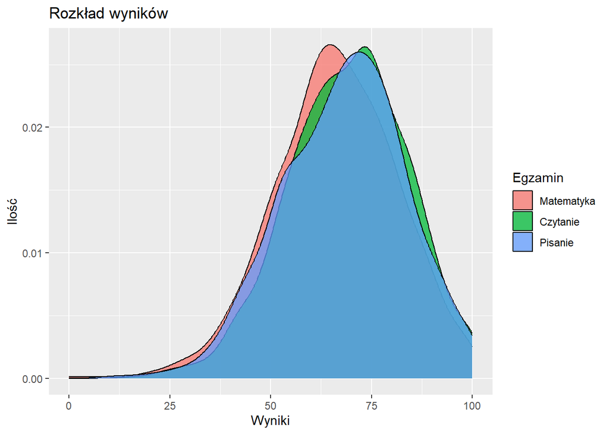

```r
# Tu umieść kod do wygenerowania odpowiedzi do zadania.

scores <- stack(df[c("math.score", "reading.score", "writing.score")])
scores <- scores %>%
  mutate(nazwa = recode(ind,
    "math.score" = "Matematyka",
    "reading.score" = "Czytanie",
    "writing.score" = "Pisanie"
  ))


plot_01 <- scores %>%
  ggplot(aes(x=values, fill=nazwa))+
  geom_density(alpha = 0.75)+
  labs(
    x = "Wyniki",
    y = "Ilość",
    title = "Rozkład wyników",
    fill = "Egzamin"
  )

plot_01
```

**Komentarz:** Rozkłady są bardzo podobne z każdego przedmiotu, mające największą ilość w okolicach 70 punktów. Wyniki z matematyki odchylone są lekko w lewo, wyniki z czytania zaś w prawo.

## Zadanie 2

Czy istnieje zauważalna różnica w wynikach między uczniami i uczennicami?

```r
library(tidyr)
```

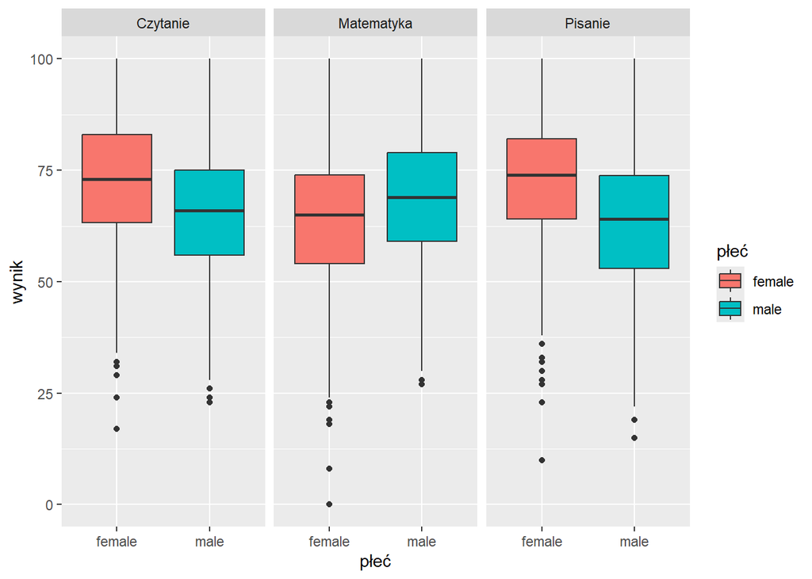

```r
df_02 <- df %>%
  pivot_longer(
    cols = ends_with(".score"),
    names_to = "exam",
    values_to = "score",
    values_drop_na = TRUE) %>%
  mutate(nazwa = recode(exam,
    "math.score" = "Matematyka",
    "reading.score" = "Czytanie",
    "writing.score" = "Pisanie"
  ))

plot_02 <- df_02 %>%
  ggplot(aes(x = gender, y = score, fill = gender))+
  geom_boxplot()+
  facet_wrap(~nazwa)+
  labs(
    x = "płeć",
    y = "wynik",
    fill = "płeć"
  )

plot_02
```

**Komentarz:** Z czytania i pisania uczennice uzyskiwły wyższe wyniki niż uczniowie, odwrtonie było z matematyką.

## Zadanie 3

Czy uczniowie, którzy ukończyli kurs przygotowawczy, osiągają lepsze wyniki niż pozostali?

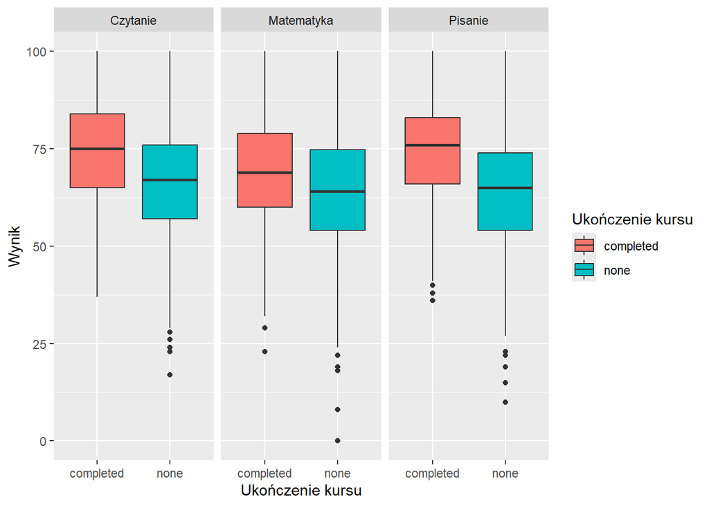

```r
plot_03 <- df_02 %>%
  ggplot(aes(x = test.preparation.course, y = score, fill = test.preparation.course))+
  geom_boxplot()+
  facet_wrap(~nazwa)+
  labs(
    x = "Ukończenie kursu",
    y = "Wynik",
    fill = "Ukończenie kursu"
  )

plot_03
```

**Komentarz:** Widać, że osoby, które wzięły udział w kursie miały wyższe wyniki z każdego przedmiotu.

## Zadanie 4

Jaki jest związek między poziomem wykształcenia rodziców a średnimi wynikami uczniów?

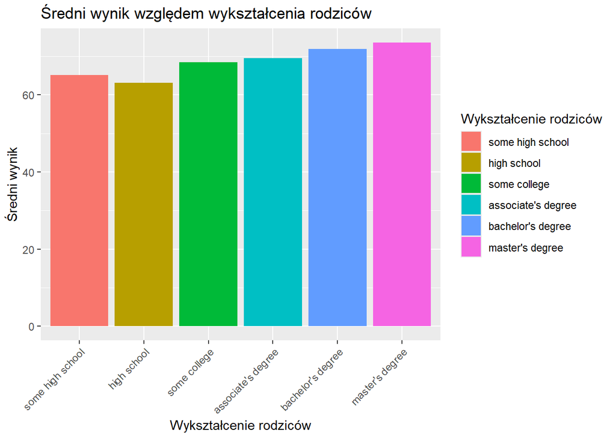

```r
education_levels <- c(
  "some high school" = 1,
  "high school" = 2,
  "some college" = 3,
  "associate's degree" = 4,
  "bachelor's degree" = 5,
  "master's degree" = 6
)


df_04 <- df %>%
  mutate(avg = (math.score + reading.score + writing.score)/3) %>%
  group_by(parental.level.of.education) %>%
  summarise(
    avg = mean(avg)
  ) %>%
  mutate(level = education_levels[parental.level.of.education]) %>%
  arrange(level) %>%
  mutate(parental.level.of.education = forcats::fct_reorder(parental.level.of.education, level))

plot_04 <- df_04 %>%
  ggplot(aes(x = parental.level.of.education, y = avg, fill = parental.level.of.education))+
  geom_col()+
  theme(axis.text.x = element_text(angle = 45, hjust = 1))+
  labs(
    x = "Wykształcenie rodziców",
    y = "Średni wynik",
    fill = "Wykształcenie rodziców",
    title = "Średni wynik względem wykształcenia rodziców"
  )

plot_04
```

**Komentarz:** Tendecja średnich wyników egzaminów jest rosnąca wraz z wykształceniem rodziców, pomijając wykształcenie średnie.

## Zadanie 5

Czy płeć i wykształcenie rodzica wpływa na wynik z matematyki?

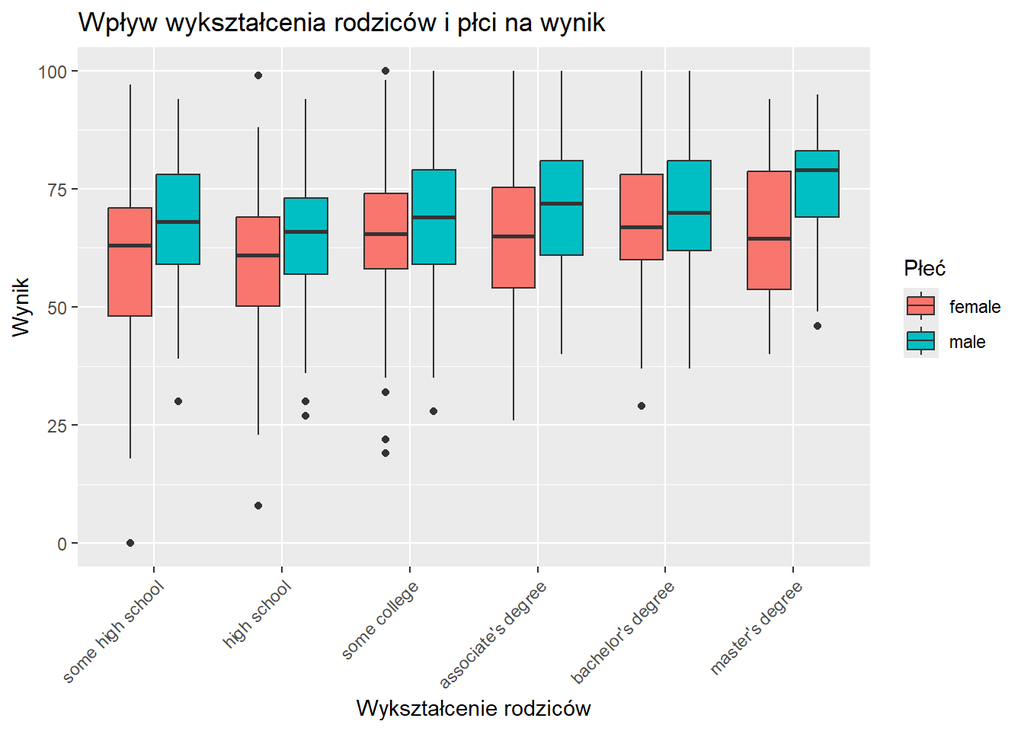

```r
plot_05 <- df %>%
  ggplot(aes(x = forcats::fct_reorder(parental.level.of.education, education_levels[parental.level.of.education]), y = math.score, fill = gender))+
  geom_boxplot()+
  labs(
    title = "Wpływ wykształcenia rodziców i płci na wynik",
    x = "Wykształcenie rodziców",
    y = "Wynik",
    fill = "Płeć"
  )+
  theme(axis.text.x = element_text(angle = 45, hjust = 1))

plot_05
```

## Zadanie 6

Czy istnieje zależność między wynikami z matematyki a wynikami z czytania lub pisania?

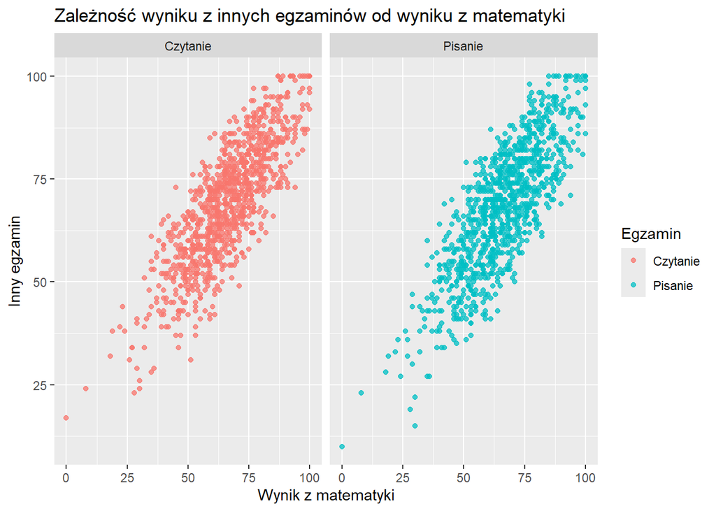

```r
df_06 <- df %>%
  pivot_longer(
    cols = c("reading.score", "writing.score"),
    names_to = "exam",
    values_to = "score"
  ) %>%
  mutate(Egzamin = recode(exam,
    "math.score" = "Matematyka",
    "reading.score" = "Czytanie",
    "writing.score" = "Pisanie"
  ))

plot_06 <- df_06 %>%
  ggplot(aes(x = math.score, y = score))+
  geom_point(alpha = 0.75, aes(colour = Egzamin))+
  facet_wrap(~ Egzamin)+
  labs(
    title = "Zależność wyniku z innych egzaminów od wyniku z matematyki",
    x = "Wynik z matematyki",
    y = "Inny egzamin",
    labs = "Egzaminy",
    fill = "Egzamin")

plot_06
```

**Komentarz:** Widać zależność liniową między wynikiem z matematyki a wynikiem z drugiego egzaminu. Im lepszy wynik z jednego, tym wyższy z drugiego.